# **The Data Behind Music and What We Like to Hear**

**Priya Kalla, Kidus Yared, and Rajan Agarwal**

**Table of Contents**

1. Introduction
2. Objective
3. Motivation
4. Data Sourcing and Info
5. Data Cleaning and Processing
6. Visualization and Exploratory Analysis
7. Machine Learning: Linear Regression
8. Machine Learning: Decision Trees
9. Conclusion/Final Thoughts

## **1. Introduction**

From the jingles you hear in commercials to the songs on the radio, music is everywhere around us. The impact music has is hard to put into words. It enhances stories and movies. It makes you want to dance. It makes you want to cry. It tells a story of culture and history and reflects the ever changing world around us. Music, itself, is so intricate and complex. Behind it there are so many different features that play into the popularity of each song and the emotions they make us feel. We should want to understand the influences of these features because they, collectively, make the music that impacts us.

Spotify was one of the first music streaming services, and due to this, the amount of data that they obtain is unrivaled. Every year, millions of users use Spotify to stream all types of music. Over time, certain genres and artists have changed in levels of popularity, so we thought it would be interesting to take a deeper dive into some of the changes that have occurred over time. Spotify's allows to get an indepth look at the music and what different audio features make different music what it is.

## **2. Objective**

The goal of this project was to be able to create a way to predict and analyze the valence and popularity of songs based off of past Spotify data. We will pull different elements and features of a song and see if we can analyze them to understand the relationships they have with popularity and valence. After getting a thorough understanding of these, we will then use machine learning to try to create regression models through which we can possibly predict popularity and valence based on different audio features. If popularity in music could be predicted, then theoretically music could be catered to fans more or optimal release windows could be determined for different types of music. Artists could have a better idea of what time of year their music would gain the most fans, and they could adjust their annual schedules accordingly. It also gives us an understanding of what people like to hear in their music. If valence could be predicted, we could get a better understanding of the music composition itself and how different aspects of music influence and are able to create certain moods.

## **3. Our Motivation**

Between the three of us, we have about 500,000 minutes combined for our Spotify wrapped for this year. Having extensive backgrounds in music, we thought that this type of data would go well with what we are interested in. Seeing as music changes so greatly over time, it would also be fascinating to look at and see if, in fact, it is possible to predict such a thing like music popularity. Kidus Yared has a job as a dancer and DJ, and using this he would be able to predict some songs that would be up and coming which are also newer so are less likely to have been heard before. This could help him stand apart from the competition in his area, and put him at an advantage to get more bookings. Being able to predict trends in music also means that more details could be revealed as to if there is any cycle of sorts when it comes to what genres may rotate in and out of popularity. Music has changed a lot over the course of the pandemic, so we also wanted to see how this may affect popularity of certain songs, or what we observed personally in 2020 was different when compared with the data from past years. We felt that with the entertainment industry changing so much, and also the fact that streaming music has caused a difference in what people are willing to try out due to not purchasing individual songs, the prediction model would be able to be improved over time as the industry changes more as long as the data is updated.

## **4. Data Sourcing and Info**

We were able to source our data from Kaggle, more specifically at https://www.kaggle.com/zaheenhamidani/ultimate-spotify-tracks-db. This data was able to span with songs from 1992 all the way through 2021. While the data does not span back this far, as Spotify was not founded until 2006, the data representing the songs can be representative of 2006 through the present in terms of trends being shown and such. The data being pulled from the Spotify API gives insight into many different categories. They are sorted as: “acousticness, danceability, energy, instrumentalness, liveness, loudness, speachiness, tempo, and valence.” For each of those, the scales and how they correspond are different. Such as “danceability” is described by Spotify as: “Danceability describes how suitable a track is for dancing based on a combination of musical elements including tempo, rhythm stability, beat strength, and overall regularity. A value of 0.0 is least danceable and 1.0 is most danceable.” This is a bit more obscure than “loudness” for instance, which is measured standardly by decibels. Other elements are also available using the API like details about the track, such as the artist, release date, genre, and popularity. The genre is a standard text label, although the popularity scale is adjusted at different times, but is represented as on a scale between 0 and 100, with 100 representing a track being the “most popular.” All of the data categories that Spotify had to give are helpful in trying to make a prediction, although to use all of them is a lot to process, so we stuck with comparing more notable aspects such as genre or acousticness with popularity.

These are the definitions for the numeric audio features contained within our selected data set as described by the Spotify Web API Reference (https://developer.spotify.com/documentation/web-api/reference/#/operations/get-audio-features):

**Acousticness:** A confidence measure from 0.0 to 1.0 of whether the track is acoustic. 1.0 represents high confidence the track is acoustic.

**Danceability:** Danceability describes how suitable a track is for dancing based on a combination of musical elements including tempo, rhythm stability, beat strength, and overall regularity. A value of 0.0 is least danceable and 1.0 is most danceable.

**Duration_ms:** The duration of the track in milliseconds.

**Energy:** A measure from 0.0 to 1.0 and represents a perceptual measure of intensity and activity. Typically, energetic tracks feel fast, loud, and noisy. For example, death metal has high energy, while a Bach prelude scores low on the scale. Perceptual features contributing to this attribute include dynamic range, perceived loudness, timbre, onset rate, and general entropy. Instrumentalness Predicts whether a track contains no vocals. "Ooh" and "aah" sounds are treated as instrumental in this context. Rap or spoken word tracks are clearly "vocal". The closer the instrumentalness value is to 1.0, the greater likelihood the track contains no vocal content. Values above 0.5 are intended to represent instrumental tracks, but confidence is higher as the value approaches 1.0.

**Liveness:** Detects the presence of an audience in the recording. Higher liveness values represent an increased probability that the track was performed live. A value above 0.8 provides strong likelihood that the track is live.

**Loudness:** The overall loudness of a track in decibels (dB). Loudness values are averaged across the entire track and are useful for comparing relative loudness of tracks. Loudness is the quality of a sound that is the primary psychological correlate of physical strength (amplitude). Values typically range between -60 and 0 db.

**Speechiness:** Detects the presence of spoken words in a track. The more exclusively speech-like the recording (e.g. talk show, audio book, poetry), the closer to 1.0 the attribute value. Values above 0.66 describe tracks that are probably made entirely of spoken words. Values between 0.33 and 0.66 describe tracks that may contain both music and speech, either in sections or layered, including such cases as rap music. Values below 0.33 most likely represent music and other non-speech-like tracks.

**Tempo:** The overall estimated tempo of a track in beats per minute (BPM). In musical terminology, tempo is the speed or pace of a given piece and derives directly from the average beat duration.

**Valence:** A measure from 0.0 to 1.0 describing the musical positiveness conveyed by a track. Tracks with high valence sound more positive (e.g. happy, cheerful, euphoric), while tracks with low valence sound more negative (e.g. sad, depressed, angry).

```python
import pandas as pd
import matplotlib.pyplot as plt
import sklearn
from sklearn.linear_model import LinearRegression
import numpy as np
```

```python
data = pd.read_csv("SpotifyFeatures.csv")
data
```

|  | genre | artist_name | track_name | track_id | popularity | acousticness | danceability | duration_ms | energy | instrumentalness | key | liveness | loudness | mode | speechiness | tempo | time_signature | valence |
| --- | --- | --- | --- | --- | --- | --- | --- | --- | --- | --- | --- | --- | --- | --- | --- | --- | --- | --- |
| 0 | Movie | Henri Salvador | C'est beau de faire un Show | 0BRjO6ga9RKCKjfDqeFgWV | 0 | 0.61100 | 0.389 | 99373 | 0.910 | 0.000000 | C# | 0.3460 | -1.828 | Major | 0.0525 | 166.969 | 4/4 | 0.814 |
| 1 | Movie | Martin & les fées | Perdu d'avance (par Gad Elmaleh) | 0BjC1NfoEOOusryehmNudP | 1 | 0.24600 | 0.590 | 137373 | 0.737 | 0.000000 | F# | 0.1510 | -5.559 | Minor | 0.0868 | 174.003 | 4/4 | 0.816 |
| 2 | Movie | Joseph Williams | Don't Let Me Be Lonely Tonight | 0CoSDzoNIKCRs124s9uTVy | 3 | 0.95200 | 0.663 | 170267 | 0.131 | 0.000000 | C | 0.1030 | -13.879 | Minor | 0.0362 | 99.488 | 5/4 | 0.368 |
| 3 | Movie | Henri Salvador | Dis-moi Monsieur Gordon Cooper | 0Gc6TVm52BwZD07Ki6tIvf | 0 | 0.70300 | 0.240 | 152427 | 0.326 | 0.000000 | C# | 0.0985 | -12.178 | Major | 0.0395 | 171.758 | 4/4 | 0.227 |
| 4 | Movie | Fabien Nataf | Ouverture | 0IuslXpMROHdEPvSl1fTQK | 4 | 0.95000 | 0.331 | 82625 | 0.225 | 0.123000 | F | 0.2020 | -21.150 | Major | 0.0456 | 140.576 | 4/4 | 0.390 |
| ... | ... | ... | ... | ... | ... | ... | ... | ... | ... | ... | ... | ... | ... | ... | ... | ... | ... | ... |
| 232720 | Soul | Slave | Son Of Slide | 2XGLdVl7lGeq8ksM6Al7jT | 39 | 0.00384 | 0.687 | 326240 | 0.714 | 0.544000 | D | 0.0845 | -10.626 | Major | 0.0316 | 115.542 | 4/4 | 0.962 |
| 232721 | Soul | Jr Thomas & The Volcanos | Burning Fire | 1qWZdkBl4UVPj9lK6HuuFM | 38 | 0.03290 | 0.785 | 282447 | 0.683 | 0.000880 | E | 0.2370 | -6.944 | Minor | 0.0337 | 113.830 | 4/4 | 0.969 |
| 232722 | Soul | Muddy Waters | (I'm Your) Hoochie Coochie Man | 2ziWXUmQLrXTiYjCg2fZ2t | 47 | 0.90100 | 0.517 | 166960 | 0.419 | 0.000000 | D | 0.0945 | -8.282 | Major | 0.1480 | 84.135 | 4/4 | 0.813 |
| 232723 | Soul | R.LUM.R | With My Words | 6EFsue2YbIG4Qkq8Zr9Rir | 44 | 0.26200 | 0.745 | 222442 | 0.704 | 0.000000 | A | 0.3330 | -7.137 | Major | 0.1460 | 100.031 | 4/4 | 0.489 |
| 232724 | Soul | Mint Condition | You Don't Have To Hurt No More | 34XO9RwPMKjbvRry54QzWn | 35 | 0.09730 | 0.758 | 323027 | 0.470 | 0.000049 | G# | 0.0836 | -6.708 | Minor | 0.0287 | 113.897 | 4/4 | 0.479 |

232725 rows × 18 columns

## **5. Data Cleaning and Processing**

###### In order to make our data easier to work with, we had to make sure that the data was “clean.” This means that we made corrections for anything that is potentially inaccurate in our data set. In doing so, we found that there were three instances of vulnerabilities in our dataset that would prevent us from developing an accurate analysis. The first is the duplication of the “Children’s Music” genre. In the initial data set, there are two genres with the title “Children’s Music” that each used a different apostrophe in the word “Children’s.” To fix this, we combined the data of the two genres under one title called “Children’s Music” by replacing the other instance of the genre name with the one that had the correct apostrophe. With this, all of the songs across both genres labelled “Children’s Music” are all under the same genre. The next potential issue we faced was the possibility of Null/NaN values in our data set. In order to mitigate this, we simply wrote code that would drop the rows containing values if they appeared in our dataset. Finally, is the issue of duplicate songs in our dataset. Looking at the data, we found that some of the songs were duplicated across genres, meaning songs would be associated with multiple genres and have all of the same characteristics other than genre. As one of our primary means of differentiating between songs in our analysis is by using genre to categorize the music, we found this to be an issue. In order to combat this. We dropped the rows containing duplicate track ids, the unique identification number for each song in the dataset, such that all instances of these track ids would be removed from the dataset. This removes the influence of these songs on all the genres it was associated with.

```python
data.genre.unique()

#first go through and make the children's music one category
data = data.replace('Children’s Music', "Children's Music")


data.isnull().any()
data = data.dropna()
data = data.drop_duplicates(subset=['track_id'], keep = False)
data = data.reset_index(drop=True)
```

## **6. Data Visualization and Exploratory Analysis**

Now that we are done cleaning the data, we want to get a better idea of the content of our data and be able to visualize the data we have.

Our first step in this process is something super simple. We want to get the number of tracks per genre. This just makes it easier to see the genres that we have in the data. This is important because as we go through our analysis we will be slicing by genre.

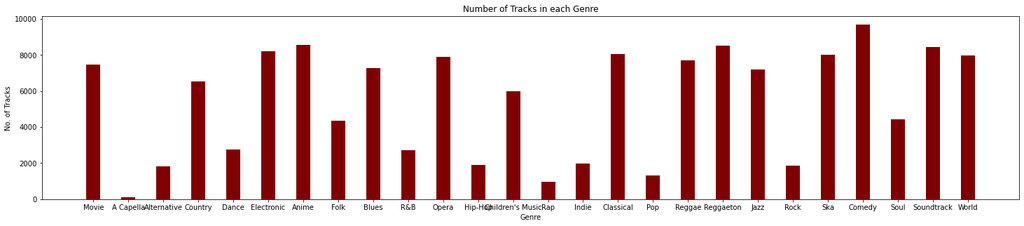

```python
genre_count = pd.DataFrame()
genre_count['genre'] = data.genre.unique()
count = []
for i, r in genre_count.iterrows():
    count.append((data.genre == r['genre']).sum())
genre_count['Number of Tracks With Genre'] = count

plt.figure(figsize=(25, 4.8))

# creating the bar plot
plt.bar(genre_count.genre, genre_count["Number of Tracks With Genre"], color ='maroon',
        width = 0.4)

plt.xlabel("Genre")
plt.ylabel("No. of Tracks")
plt.title("Number of Tracks in each Genre")
plt.show()
```

Now, we have a general idea about the number of genre's and the frequency of the genre's in our data set. We know want to examine some of the other features over genre. As mentioned before our data contains a variety of audio based features as well as popularity. Popularity is something we're very interested in because we want to get an understanding of what audio features, if any, influence popularity. Another one that we want to look at is valence. Valence, as mentioned earlier, is about the mood of the music. The higher the valence the more positive the sound (happy, cheerful) and the lower the valence the more negative (sad, angry). This would be an interesting feature to see what other audio features influence it.

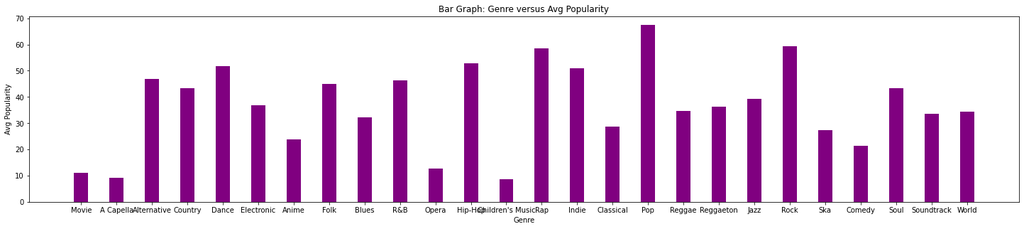

```python
popular_by_genre = pd.DataFrame()
popular_by_genre['genre'] = data.genre.unique()
avgpop = []

for g in data.genre.unique():
    p = (data.groupby('genre').get_group(g)['popularity']).mean()
    avgpop.append(p)

popular_by_genre['Avg Pop Per Genre'] = avgpop
plt.figure(figsize=(25, 4.8))

# creating the bar plot
plt.bar(popular_by_genre.genre, popular_by_genre['Avg Pop Per Genre'], color ='purple',
        width = 0.4)

plt.xlabel("Genre")
plt.ylabel("Avg Popularity")
plt.title("Bar Graph: Genre versus Avg Popularity")
plt.show()
```

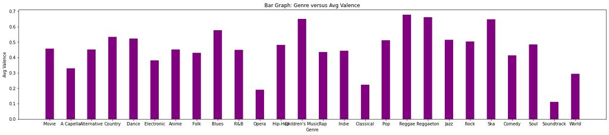

```python
popular_by_genre = pd.DataFrame()
popular_by_genre['genre'] = data.genre.unique()
avgval = []

for g in data.genre.unique():
    v = (data.groupby('genre').get_group(g)['valence']).mean()
    avgval.append(v)

popular_by_genre['Avg Val Per Genre'] = avgval
plt.figure(figsize=(25, 4.8))

# creating the bar plot
plt.bar(popular_by_genre.genre, popular_by_genre['Avg Val Per Genre'], color ='purple',
        width = 0.4)

plt.xlabel("Genre")
plt.ylabel("Avg Valence")
plt.title("Bar Graph: Genre versus Avg Valence")
plt.show()
```

**Popularity:**

Based on the plot "Bar Graph: Genre versus Avg Popularity", we can see which genres have, in general, a higher average popularity. Pop, Rap, Rock, Hip-Hip, and Dance have the highest average popularity among the genres listed. This makes sense because they are the more common genres we see in music.

**Valence:**

Based on the plot "Bar Graph: Genre versus Avg Valence", we can see which genres have, in general, a higher average valence. Children's Music, Reggae, Reggaton, Ska, and Blues have the highest average valence among the genres. Blues is kind of suprising, but the other genres are to be expected. Also makes sense that Opera, Soundtrack, and classical have a lower valence.

While these graphs give us some insight, to get a better understanding we want to use a plot that could give us a more thorough look at the distribution. For that reason, we are going to create boxplots.

The boxplots will provide descriptive and robust statistics of popularity and valence across the genres of music shown in our dataset. These statistics include median, interquartile range, and outliers of each genre's popularity and valence. From these, we gain a general sense of how each genre's popularity and valence compares to each other. The yellow/orange bar in each box will mark the median of the numeric value we are plotting for each genre. This provides us with robust measurement of location for the feature's average against these genres. With this we will then identify which genres have the highest and lowest average in terms of each feature, popularity or valence. Robust means that the statistic performs well against errors or exceptions within the data. The Interquartile range (IQR) shows the spread of the middle half of our data (within the 25% and 75% mark of a genre's popularity or valence). This measure shows the variability of the data and can be found looking at the top and bottom edges of the boxes. The circles above and below the boxes show the outlier data in terms of popularity for each genre. An outlier is defined by whether or not they lie within the minimum and maximum whiskers of the boxplot.

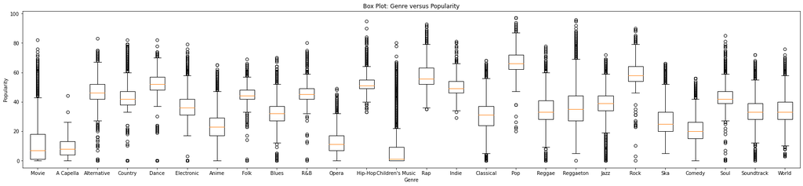

```python
popularity_by_genre = {}
for index, row in data.iterrows():
    if row['genre'] in popularity_by_genre.keys():
        popularity_by_genre[row['genre']].append(row['popularity'])
    else:
        popularity_by_genre[row['genre']] = [row['popularity']]
fig, ax = plt.subplots(figsize=(29, 6))
ax.boxplot(popularity_by_genre.values())
ax.set_xticklabels(popularity_by_genre.keys())

ax.set_xlabel("Genre")
ax.set_ylabel("Popularity")
ax.set_title("Box Plot: Genre versus Popularity")
plt.show()
```

Looking at this, we can see that Pop music has the highest median popularity, closely followed by Rock, Rap, and Dance music. On the bottom end, we see that children's music has lowest median popularity followed by Movie and A Capella music. Among the genres in the plot, we can see that Hip-Hop, Folk, and R&B have the tightest distributions, meaning that most of the data is centered closely around the median for these genres. Alternatively, Movie, Reggaeton, and Classical music appear to have the largest IQRs, showing that more of its data has more distance from the median. In the plot of the genre's we observe that generally outliers have a higher popularity than the majority of data for each genre.

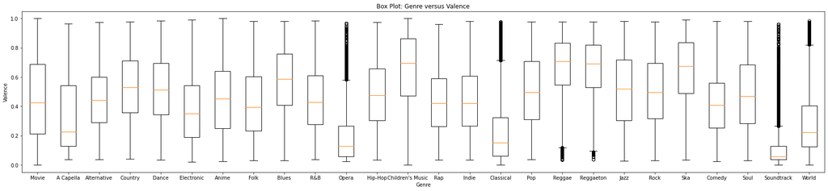

```python
genre_val = {}
for index, row in data.iterrows():
    if row['genre'] in genre_val.keys():
        genre_val[row['genre']].append(row['valence'])
    else:
        genre_val[row['genre']] = [row['valence']]

fig, ax = plt.subplots(figsize=(29, 6))
ax.boxplot(genre_val.values())
ax.set_xticklabels(genre_val.keys())

ax.set_xlabel("Genre")
ax.set_ylabel("Valence")
ax.set_title("Box Plot: Genre versus Valence")
plt.show()
```

Looking at the boxplot of valence by genre, we can derive all of the same statistical information as we did with the boxplot of popularity by genre. First, we find that Reggae music has the highest median valence, closely followed by Reggaeton, Ska, and Children’s music. On the bottom end, we see that Soundtrack music has lowest median valence followed by Opera and Classical music. Among the genres in the plot, we can see that Soundtrack, Opera, and Classical music have the tightest distributions looking at their IQRs. Alternatively, Movie, Jazz, and Soul music appear to have the largest IQRs. In the plot of the genre's we observe that generally outliers have a higher valence than the majority of data for each genre.

Now we are going to look at the relationships between valence and the other audio features and popularity and the other audio features. We will be slicing and breaking up the data by genre. We decided to slice by genre because looking at all the data without some organization is overwhelming and very unclear. For example, if we just did a scatterplot of Acousticness versus Popularity without any slicing and organization it would look like this:

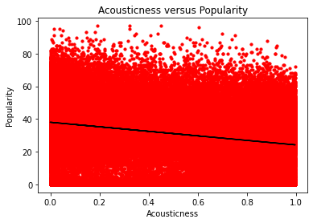

```python
plt.scatter(data["acousticness"], data["popularity"], s =10, c = "red")

plt.xlabel("Acousticness", size=10)
plt.ylabel("Popularity", size=10)
plt.title("Acousticness versus Popularity")

m, b = np.polyfit(data["acousticness"], data["popularity"], 1)
plt.plot(data["acousticness"], m*(data["acousticness"])+b, color = "black")

plt.show()
```

The graph has too much data on it and is impossible to read therefore incredibly unhelpful. That is the reason for why we will be slicing by genre.

Before we start making any plots, our first step is to slice the data by genre and then calculate the averages of the audio features (acousticness, danceability, loudness, energy, instrumentalness, speechiness, tempo, valence) for each genre and do the same for popularity.

```python
#acousticness, danceability, loudness, energy, instrumentalness, speechiness, tempo, valence

#start by grouping together the genres
data_genre = data.groupby('genre')
avg_acous_col = []
avg_dance_col = []
avg_loud_col = []
avg_egy_col = []
avg_instr_col = []
avg_speech_col = []
avg_tmp_col = []
avg_vl_col = []
avg_pop_col = []

#for each of the features calculate the average of it within the specific genre
for g in data.genre.unique():
    avg_acous = (data_genre.get_group(g)['acousticness']).mean()
    avg_acous_col.append(avg_acous)

    avg_dn = (data_genre.get_group(g)['danceability']).mean()
    avg_dance_col.append(avg_dn)

    avg_ld = (data_genre.get_group(g)['loudness']).mean()
    avg_loud_col.append(avg_ld)

    avg_e = (data_genre.get_group(g)['energy']).mean()
    avg_egy_col.append(avg_e)

    avg_in = (data_genre.get_group(g)['instrumentalness']).mean()
    avg_instr_col.append(avg_in)

    avg_sp = (data_genre.get_group(g)['speechiness']).mean()
    avg_speech_col.append(avg_sp)

    avg_t = (data_genre.get_group(g)['tempo']).mean()
    avg_tmp_col.append(avg_t)

    avg_v = (data_genre.get_group(g)['valence']).mean()
    avg_vl_col.append(avg_v)

    avg_p = (data_genre.get_group(g)['popularity']).mean()
    avg_pop_col.append(avg_p)

#create a new dataframe to hold these averages
genre_count['Avg Acoust'] = avg_acous_col
genre_count['Avg Dance'] = avg_dance_col
genre_count['Avg Loud'] = avg_loud_col
genre_count['Avg Energy'] = avg_egy_col
genre_count['Avg Instru'] = avg_instr_col
genre_count['Avg Speech'] = avg_speech_col
genre_count['Avg Tempo'] = avg_tmp_col
genre_count['Avg Val'] = avg_vl_col
genre_count['Avg Pop'] = avg_pop_col
genre_count
```

|  | genre | Number of Tracks With Genre | Avg Acoust | Avg Dance | Avg Loud | Avg Energy | Avg Instru | Avg Speech | Avg Tempo | Avg Val | Avg Pop |
| --- | --- | --- | --- | --- | --- | --- | --- | --- | --- | --- | --- |
| 0 | Movie | 7480 | 0.693258 | 0.497294 | -12.744472 | 0.378010 | 0.105562 | 0.112148 | 114.197409 | 0.456952 | 11.162433 |
| 1 | A Capella | 119 | 0.829941 | 0.412252 | -13.660387 | 0.250313 | 0.007491 | 0.042414 | 111.518950 | 0.328724 | 9.302521 |
| 2 | Alternative | 1817 | 0.170842 | 0.549495 | -6.630140 | 0.716337 | 0.068120 | 0.094833 | 123.046429 | 0.452183 | 46.841497 |
| 3 | Country | 6526 | 0.266765 | 0.578043 | -7.186923 | 0.641118 | 0.004114 | 0.049120 | 123.987203 | 0.532664 | 43.231229 |
| 4 | Dance | 2738 | 0.135449 | 0.636600 | -5.724598 | 0.737828 | 0.043247 | 0.077836 | 122.022745 | 0.521202 | 51.743243 |
| 5 | Electronic | 8186 | 0.107848 | 0.619469 | -6.785214 | 0.752051 | 0.343693 | 0.103370 | 126.815279 | 0.381457 | 36.863670 |
| 6 | Anime | 8556 | 0.269837 | 0.477628 | -7.561789 | 0.680136 | 0.261828 | 0.065671 | 127.414306 | 0.451979 | 23.888967 |
| 7 | Folk | 4342 | 0.501263 | 0.522200 | -10.325767 | 0.462917 | 0.091926 | 0.046051 | 118.566483 | 0.430757 | 45.004606 |
| 8 | Blues | 7255 | 0.316733 | 0.523391 | -8.985729 | 0.617802 | 0.103960 | 0.062778 | 121.724835 | 0.578137 | 32.093177 |
| 9 | R&B | 2725 | 0.282003 | 0.642277 | -7.382235 | 0.576216 | 0.025704 | 0.130579 | 117.631531 | 0.447904 | 46.275229 |
| 10 | Opera | 7891 | 0.945335 | 0.291114 | -19.320618 | 0.168494 | 0.229850 | 0.059371 | 101.866712 | 0.190235 | 12.705867 |
| 11 | Hip-Hop | 1903 | 0.195898 | 0.725938 | -7.007624 | 0.645662 | 0.017129 | 0.214923 | 122.601051 | 0.482935 | 52.937467 |
| 12 | Children's Music | 6006 | 0.548597 | 0.679103 | -11.104936 | 0.429867 | 0.132963 | 0.113716 | 121.280151 | 0.649602 | 8.651515 |
| 13 | Rap | 982 | 0.251441 | 0.707508 | -7.697729 | 0.598514 | 0.031258 | 0.201147 | 119.833145 | 0.434643 | 58.511202 |
| 14 | Indie | 1974 | 0.329022 | 0.563626 | -7.827679 | 0.589585 | 0.104004 | 0.063514 | 121.240024 | 0.444015 | 50.901722 |
| 15 | Classical | 8042 | 0.872682 | 0.311555 | -21.817642 | 0.175878 | 0.602429 | 0.052147 | 104.617212 | 0.222763 | 28.651455 |
| 16 | Pop | 1329 | 0.293093 | 0.623026 | -6.210878 | 0.647998 | 0.024443 | 0.076913 | 122.550709 | 0.510723 | 67.404063 |
| 17 | Reggae | 7689 | 0.183321 | 0.698963 | -7.449307 | 0.639561 | 0.037165 | 0.119524 | 118.207661 | 0.676880 | 34.658863 |
| 18 | Reggaeton | 8526 | 0.219886 | 0.730310 | -5.913187 | 0.748450 | 0.003719 | 0.128248 | 121.008886 | 0.660007 | 36.395496 |
| 19 | Jazz | 7185 | 0.510011 | 0.584280 | -11.270528 | 0.470373 | 0.386490 | 0.073973 | 111.894777 | 0.513024 | 39.165344 |
| 20 | Rock | 1865 | 0.208501 | 0.509611 | -8.099151 | 0.672042 | 0.067755 | 0.055619 | 123.409935 | 0.504130 | 59.229491 |
| 21 | Ska | 8016 | 0.087716 | 0.510709 | -5.968571 | 0.836905 | 0.056921 | 0.088303 | 130.807475 | 0.647304 | 27.439371 |
| 22 | Comedy | 9673 | 0.793455 | 0.559015 | -11.693328 | 0.676209 | 0.000574 | 0.854173 | 98.213386 | 0.412638 | 21.317068 |
| 23 | Soul | 4418 | 0.354076 | 0.615752 | -8.743009 | 0.547912 | 0.063993 | 0.082536 | 115.675149 | 0.484146 | 43.451335 |
| 24 | Soundtrack | 8446 | 0.708439 | 0.261246 | -19.282070 | 0.223969 | 0.790962 | 0.043545 | 104.009680 | 0.112301 | 33.692872 |
| 25 | World | 7961 | 0.379411 | 0.443510 | -10.322094 | 0.516744 | 0.206401 | 0.045281 | 120.473883 | 0.294787 | 34.394548 |

#### **Valence Graphs**

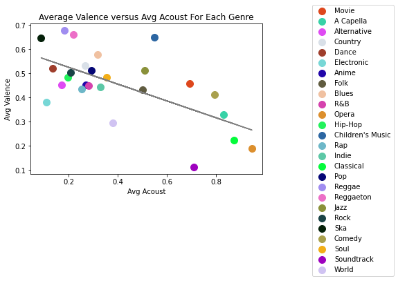

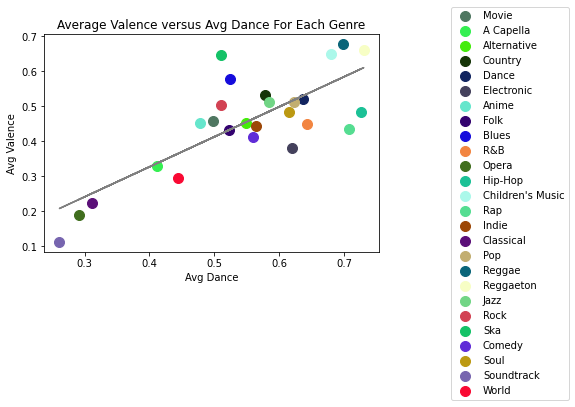

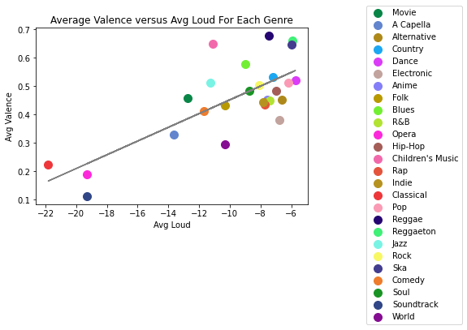

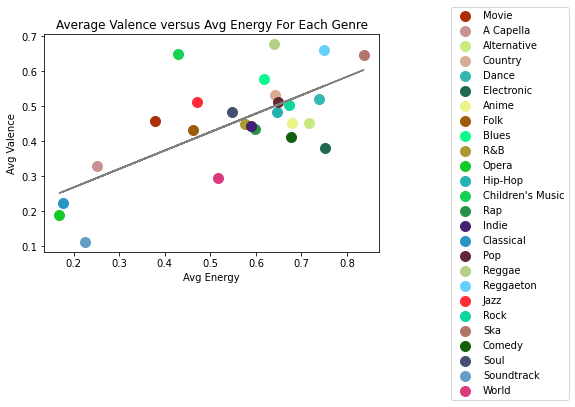

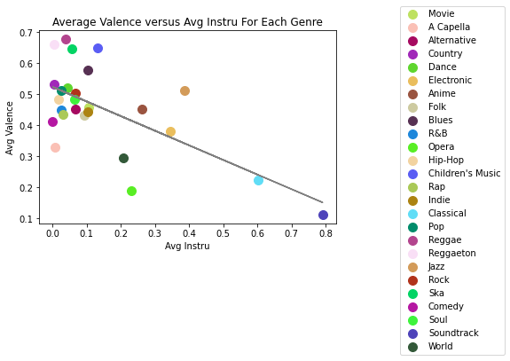

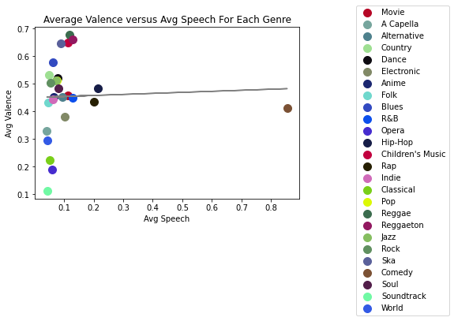

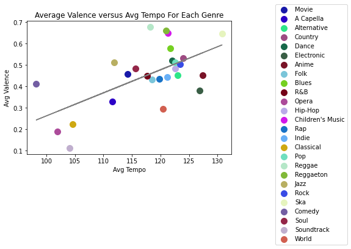

```python
audio_features = ['Avg Acoust', 'Avg Dance','Avg Loud','Avg Energy','Avg Instru','Avg Speech','Avg Tempo']
for a in audio_features:
    sequence = np.arange(len(data.genre.unique()))
    for co in sequence:
        rgb = np.random.rand(3,)
        plt.scatter(genre_count[a][co], genre_count['Avg Val'][co], s =100, c = [rgb], label = list(genre_count["genre"])[co])


    plt.ylabel("Avg Valence", size=10)
    plt.xlabel(a, size=10)
    plt.title("Average Valence versus " + a + " For Each Genre")
    plt.legend(loc="upper left", bbox_to_anchor=(1.2, 1.15))

    m, b = np.polyfit(genre_count[a], genre_count['Avg Val'], 1)
    plt.plot(genre_count[a], m*(genre_count[a])+b, color = "gray")

    plt.show()
```

So what do the graphs tell us about the relationship between valence and the different audio features?

**Acousticness:**

**Danceability:**

The graph of the average danceability against average valence for each genre has an upward trend as depicted by the positive slope of the line of best fit, showing that generally valence tends to increase as danceability increases. The data seems to be mostly evenly distributed across danceability; It seems that there are points across the plot that are close to the line of best fit and we can clearly see the points lie farther and farther up the valence axis as danceability increases. This leads us to believe that there is a very strong relationship between danceability and valence as opposed to other features.

**Loudness:**

The graph of the average loudness against average valence for each genre has an upward trend as depicted by the positive slope of the line of best fit, showing that valence generally tends to increase as loudness increases.The majority of the data lies above -14 loudness. This shows us that music tends to be made at this volume or higher and that those considerably below this volume are exceptions. Even with this cluster of data in the upper range of loudness, the positive trend of valence as loudness increases is visually prominent. Because of this, it seems that there is a strong correlation between loudness and valence.

**Energy:**

**Instrumentalness:**

The graph of the average instrumentalness against average valence for each genre has a downward trend as depicted by the negative slope of the line of best fit, showing that valence generally tends to increase as instrumentalness decreases. Most of the data lies below 0.15 instrumentalness and for the points within this range the mostly lie above 0.4 on the valence axis. For the remaining points above 0.15 instrumentalness, they mostly fall below 0.4 valence. Based on this, we can say that there is a visual indication of the negative trend of valence across instrumentalness. However, it is difficult to tell how strongly correlated these variables are due to the large cluster of points in the plot.

**Speechiness:**

The graph of the average speechiness against average valence for each genre has a slight upward trend as depicted by the positive slope of best fit, showing that valence generally tends to increase as speechiness increases. Similarly to instrumentalness, most of the dat falls below 0.2 speechiness. Additionally, for the points within this range of speechiness, the range of valence goes from 0.1 to 0.7. Due to this distribution of the data, it is difficult to determine how strong the relationship between valence and speechiness is as it was with instrumentalness.

**Tempo:**

The graph of the average tempo against average valence for each genre has an upward trend as depicted by the positive slope of the line of best fit, showing that valence generally tends to increase as tempo increases. The data is more evenly distributed as opposed to the instrumentalness and speechiness. Looking at the graph, we found that for some of the data the positive trend of valence is noticeable. However, it is just as noticeable visually that there are some points that do not follow the trend well. Based on this, we expect that tempo will have a significant correlation with valence but not as much as those that are much more clearly related to valence like loudness and energy.

#### **Popularity Graphs**

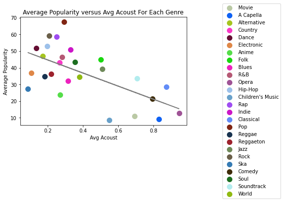

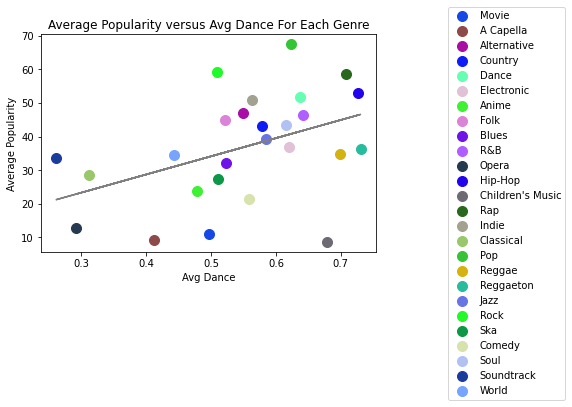

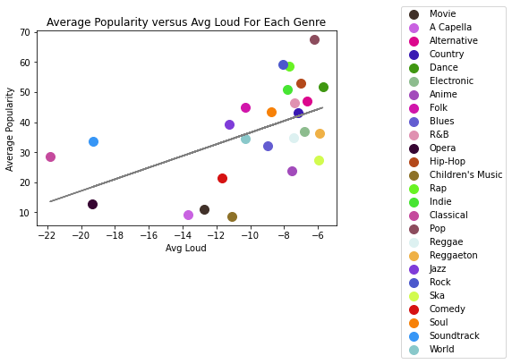

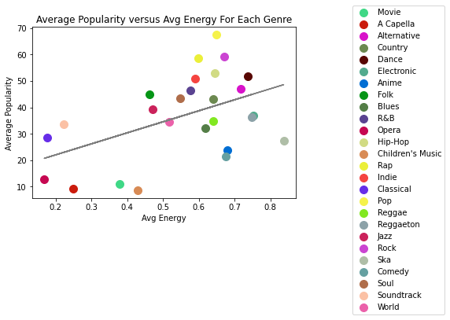

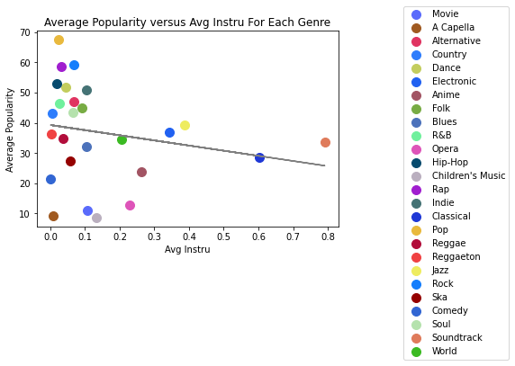

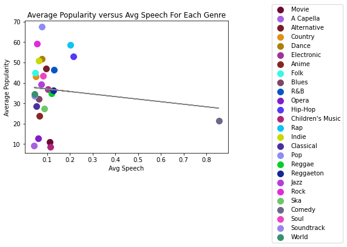

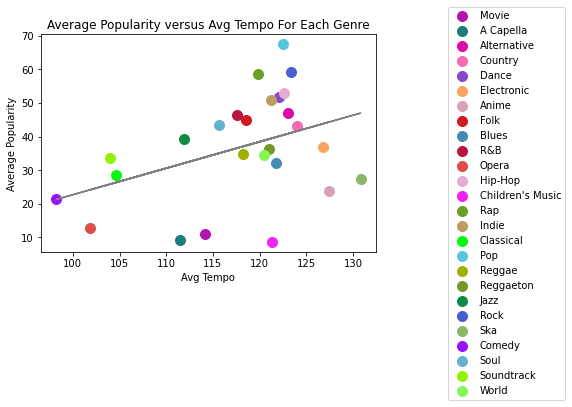

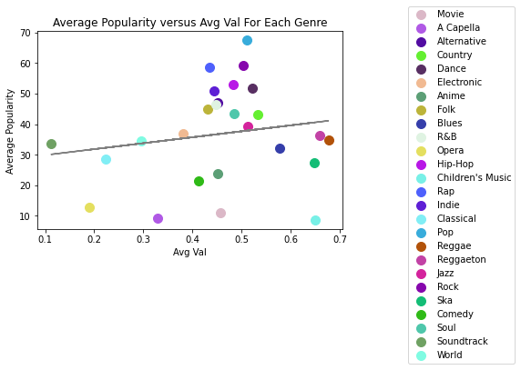

```python
audio_features = ['Avg Acoust', 'Avg Dance','Avg Loud','Avg Energy','Avg Instru','Avg Speech','Avg Tempo','Avg Val']
for a in audio_features:
    sequence = np.arange(len(data.genre.unique()))
    for co in sequence:
        rgb = np.random.rand(3,)
        plt.scatter(genre_count[a][co], genre_count['Avg Pop'][co], s =100, c = [rgb], label = list(genre_count["genre"])[co])


    plt.ylabel("Average Popularity", size=10)
    plt.xlabel(a, size=10)
    plt.title("Average Popularity versus " + a + " For Each Genre")
    plt.legend(loc="upper left", bbox_to_anchor=(1.2, 1.15))

    m, b = np.polyfit(genre_count[a], genre_count['Avg Pop'], 1)
    plt.plot(genre_count[a], m*(genre_count[a])+b, color = "gray")

    plt.show()
```

So what do the graphs tell us about the relationship between popularity and the different audio features?

**Acousticness:**

The graph of the average acousticness against average popularity for each genre has a downward trend as depicted by the negative slope of the line of best fit, showing that popularity generally tends to increase as acousticness decreases. There does not appear to be a strong correlation between acousticness and popularity however we can see that most genres have low acousticness. The graph appears to have two clusters of genres - one toward the low end of acousticness and one toward the high end of acousticness. Not many genres fall in the mid range of acousticness. It is possible that this is because it is difficult to create appealing music that blends acoustic and non-acoustic elements.

**Danceability:**

The graph of the average danceability against average popularity for each genre has an upward trend as depicted by the positive slope of the line of best fit, showing that popularity generally tends to increase as danceability increases. The data seems to have a greater distribution in this category than acousticness; there are not very prominent clusters of genres across the plot. It seems that there are points across the plot that are close to the line of best fit. However, the steepness of the regression line seems to be slightly less than that of acousticness.

**Loudness:**

**Energy:**

The graph of the average energy against average popularity for each genre has an upward trend as indicated by the positive slope of the line of best fit, showing that popularity generally tends to increase as energy increases. Most of the data lies above the 0.5 energy mark. This shows us most genres in general tend to have a higher energy level. However, for genres with higher energy, the average popularity ranges between about 20 to 70. Based on how spread out the data, there does not seem to be a strong correlation between energy and popularity.

**Instrumentalness:**

The graph of the average instrumentalness against average popularity for each genre has a downward trend as depicted by the negative slope of the line of best fit, showing that popularity generally tends to increase as instrumentalness decreases. The vast majority of the data lies between 0.0 and 0.15 instrumentalness. Based on this, we can gather that many genres tend to have low instrumentalness. Additionally, among the genres that lie within this range of instrumentalness, the average popularity ranges between about 10 and 70. Based on this, we do not expect a correlation between instrumentalness and popularity.

**Speechiness:**

The graph of the average speechiness against average popularity for each genre has a downward trend as depicted by the negative slope of best fit, showing that popularity generally tends to increase as speechiness decreases. Similarly to instrumentalness, the vast majority of the data lies between 0.0 and 0.2 speechiness. Among the genres that lie within this range of speechiness, the average popularity ranges between about 70% and 10%. Based on this, we can conclude that music in general tends to have low speechiness, and we do not expect a correlation between speechiness and popularity.

**Tempo:**

The graph of the average tempo against average popularity for each genre has an upward trend as depicted by the positive slope of the line of best fit, showing that popularity generally tends to increase as tempo increases. There is a more even distribution of the data as opposed to the other plots as there are not as intense clusters of points across the plot. Most of the data does seem to lie above the 115 bpm mark of tempo. Based on this, we expect that tempo will have a higher correlation to popularity than some of the features but not those with a relatively strong correlation.

**Valence:**

The graph of the average valence against average popularity for each genre has an upward trend as depicted by the slight positive slope of the line of best fit, showing that popularity generally tends to increase as valence increases. The plot of valence also appears to have a more even distribution of the data as opposed to other features with only a small cluster of points among the genres with the most average popularity. With the spread of points that lie outside of this range of popularity, it is difficult to tell whether or not there is a correlation between popularity and valence.

#### **Now, we're going to standardize**

We standardize when comparing the effects of variables with unequal units, e.g. does age or education have a larger effect on income? The standardization of a variable essentially centers and scales the data. It transforms the data into a unitless scale. This will help make it more easy to interpret and help us get a better comprehension of the data. For more insight into standardization, look here: https://www.ohdsi.org/data-standardization/. We will be using the formula below.

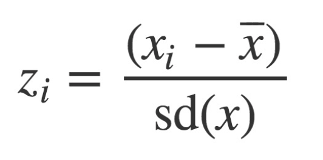

We are going to follow a very similar process to the one above. We are going to calculate the standardized values for each audio feature. Add them to the large dataset. We are then going to go through and calculate the average of each standardized varible so we can replot.

```python
#create a new dataframe to now also include the standardized values
data_stand = data.copy()
#function created to standarize the audio features
def standardize (df, audiofeature):
    stndrd = (df[audiofeature] - (df[audiofeature].mean())) / (df[audiofeature].std())
    return stndrd
#go through all the features and standardize them
afeatures = ['acousticness', 'danceability', 'loudness', 'energy', 'instrumentalness', 'speechiness', 'tempo', 'valence']
for af in afeatures:
    stnd = standardize(data_stand, af)
    title = 'stand_' + af[:4]
    data_stand[title] = stnd

#display the new dataframe
data_stand
```

|  | genre | artist_name | track_name | track_id | popularity | acousticness | danceability | duration_ms | energy | instrumentalness | ... | time_signature | valence | stand_acou | stand_danc | stand_loud | stand_ener | stand_inst | stand_spee | stand_temp | stand_vale |
| --- | --- | --- | --- | --- | --- | --- | --- | --- | --- | --- | --- | --- | --- | --- | --- | --- | --- | --- | --- | --- | --- |
| 0 | Movie | Henri Salvador | C'est beau de faire un Show | 0BRjO6ga9RKCKjfDqeFgWV | 0 | 0.6110 | 0.389 | 99373 | 0.910 | 0.000000 | ... | 4/4 | 0.814 | 0.466309 | -0.720786 | 1.317753 | 1.275424 | -0.571111 | -0.370484 | 1.587101 | 1.327853 |
| 1 | Movie | Martin & les fées | Perdu d'avance (par Gad Elmaleh) | 0BjC1NfoEOOusryehmNudP | 1 | 0.2460 | 0.590 | 137373 | 0.737 | 0.000000 | ... | 4/4 | 0.816 | -0.510097 | 0.317797 | 0.760891 | 0.671183 | -0.571111 | -0.215953 | 1.809153 | 1.335132 |
| 2 | Movie | Joseph Williams | Don't Let Me Be Lonely Tonight | 0CoSDzoNIKCRs124s9uTVy | 3 | 0.9520 | 0.663 | 170267 | 0.131 | 0.000000 | ... | 5/4 | 0.368 | 1.378513 | 0.694994 | -0.480893 | -1.445405 | -0.571111 | -0.443920 | -0.543165 | -0.295422 |
| 3 | Movie | Henri Salvador | Dis-moi Monsieur Gordon Cooper | 0Gc6TVm52BwZD07Ki6tIvf | 0 | 0.7030 | 0.240 | 152427 | 0.326 | 0.000000 | ... | 4/4 | 0.227 | 0.712417 | -1.490680 | -0.227014 | -0.764324 | -0.571111 | -0.429053 | 1.738282 | -0.808610 |
| 4 | Movie | Fabien Nataf | Ouverture | 0IuslXpMROHdEPvSl1fTQK | 4 | 0.9500 | 0.331 | 82625 | 0.225 | 0.123000 | ... | 4/4 | 0.390 | 1.373163 | -1.020476 | -1.566111 | -1.117089 | -0.207740 | -0.401570 | 0.753917 | -0.215350 |
| ... | ... | ... | ... | ... | ... | ... | ... | ... | ... | ... | ... | ... | ... | ... | ... | ... | ... | ... | ... | ... | ... |
| 141645 | Soul | John Legend | Quickly (feat. Brandy) | 1U0OMWvR89Cm20vCNar50f | 39 | 0.2310 | 0.736 | 222667 | 0.701 | 0.000000 | ... | 4/4 | 0.770 | -0.550224 | 1.072191 | 0.942084 | 0.545445 | -0.571111 | -0.156484 | -0.527287 | 1.167709 |
| 141646 | Soul | Belly | P.O.P. | 2gGqKJWfWbToha2YmDxnnj | 43 | 0.1040 | 0.802 | 201173 | 0.516 | 0.000485 | ... | 4/4 | 0.482 | -0.889959 | 1.413218 | 0.245222 | -0.100708 | -0.569679 | 0.352612 | 1.861652 | 0.119496 |
| 141647 | Soul | Bobby "Blue" Bland | I'll Take Care Of You - Single Version | 2iZf3EUedz9MPqbAvXdpdA | 32 | 0.5660 | 0.423 | 144667 | 0.337 | 0.000000 | ... | 4/4 | 0.497 | 0.345930 | -0.545105 | -0.363431 | -0.725905 | -0.571111 | -0.410581 | -1.157644 | 0.174090 |
| 141648 | Soul | Jr Thomas & The Volcanos | Burning Fire | 1qWZdkBl4UVPj9lK6HuuFM | 38 | 0.0329 | 0.785 | 282447 | 0.683 | 0.000880 | ... | 4/4 | 0.969 | -1.080158 | 1.325378 | 0.554175 | 0.482576 | -0.568512 | -0.455183 | -0.090412 | 1.891996 |
| 141649 | Soul | Mint Condition | You Don't Have To Hurt No More | 34XO9RwPMKjbvRry54QzWn | 35 | 0.0973 | 0.758 | 323027 | 0.470 | 0.000049 | ... | 4/4 | 0.479 | -0.907882 | 1.185867 | 0.589399 | -0.261373 | -0.570967 | -0.477709 | -0.088296 | 0.108577 |

141650 rows × 26 columns

```python
#standarized acousticness, danceability, loudness, energy, instrumentalness, speechiness, tempo, valence

#calculate the avergage of each standardized variable for each genre (same way we did earlier)
data_genre = data_stand.groupby('genre')
avg_ac_std = []
avg_dnc_std = []
avg_loud_std = []
avg_egy_std = []
avg_instr_std = []
avg_speech_std = []
avg_tmp_std = []
avg_vl_std = []

for g in data_stand.genre.unique():
    avg_std = (data_genre.get_group(g)['stand_acou']).mean()
    avg_ac_std.append(avg_std)

    avg_dn = (data_genre.get_group(g)['stand_danc']).mean()
    avg_dnc_std.append(avg_dn)

    avg_ld = (data_genre.get_group(g)['stand_loud']).mean()
    avg_loud_std.append(avg_ld)

    avg_e = (data_genre.get_group(g)['stand_ener']).mean()
    avg_egy_std.append(avg_e)

    avg_in = (data_genre.get_group(g)['stand_inst']).mean()
    avg_instr_std.append(avg_in)

    avg_sp = (data_genre.get_group(g)['stand_spee']).mean()
    avg_speech_std.append(avg_sp)

    avg_t = (data_genre.get_group(g)['stand_temp']).mean()
    avg_tmp_std.append(avg_t)

    avg_v = (data_genre.get_group(g)['stand_vale']).mean()
    avg_vl_std.append(avg_v)



genre_count['Avg Stand Acoust'] = avg_ac_std
genre_count['Avg Stand Dance'] =avg_dnc_std
genre_count['Avg Stand Loud'] = avg_loud_std
genre_count['Avg Stand Energy'] =avg_egy_std
genre_count['Avg Stand Instru'] = avg_instr_std
genre_count['Avg Stand Speech'] = avg_speech_std
genre_count['Avg Stand Tempo'] = avg_tmp_std
genre_count['Avg Stand Val'] = avg_vl_std
genre_count
```

|  | genre | Number of Tracks With Genre | Avg Acoust | Avg Dance | Avg Loud | Avg Energy | Avg Instru | Avg Speech | Avg Tempo | Avg Val | Avg Pop | Avg Stand Acoust | Avg Stand Dance | Avg Stand Loud | Avg Stand Energy | Avg Stand Instru | Avg Stand Speech | Avg Stand Tempo | Avg Stand Val |
| --- | --- | --- | --- | --- | --- | --- | --- | --- | --- | --- | --- | --- | --- | --- | --- | --- | --- | --- | --- |
| 0 | Movie | 7480 | 0.693258 | 0.497294 | -12.744472 | 0.378010 | 0.105562 | 0.112148 | 114.197409 | 0.456952 | 11.162433 | 0.686355 | -0.161221 | -0.311562 | -0.582667 | -0.259257 | -0.101755 | -0.078813 | 0.028332 |
| 1 | A Capella | 119 | 0.829941 | 0.412252 | -13.660387 | 0.250313 | 0.007491 | 0.042414 | 111.518950 | 0.328724 | 9.302521 | 1.051995 | -0.600640 | -0.448265 | -1.028679 | -0.548981 | -0.415923 | -0.163368 | -0.438371 |
| 2 | Alternative | 1817 | 0.170842 | 0.549495 | -6.630140 | 0.716337 | 0.068120 | 0.094833 | 123.046429 | 0.452183 | 46.841497 | -0.711153 | 0.108506 | 0.601020 | 0.599012 | -0.369869 | -0.179763 | 0.200536 | 0.010974 |
| 3 | Country | 6526 | 0.266765 | 0.578043 | -7.186923 | 0.641118 | 0.004114 | 0.049120 | 123.987203 | 0.532664 | 43.231229 | -0.454548 | 0.256013 | 0.517918 | 0.336295 | -0.558959 | -0.385712 | 0.230235 | 0.303893 |
| 4 | Dance | 2738 | 0.135449 | 0.636600 | -5.724598 | 0.737828 | 0.043247 | 0.077836 | 122.022745 | 0.521202 | 51.743243 | -0.805830 | 0.558584 | 0.736175 | 0.674075 | -0.443350 | -0.256340 | 0.168220 | 0.262177 |
| 5 | Electronic | 8186 | 0.107848 | 0.619469 | -6.785214 | 0.752051 | 0.343693 | 0.103370 | 126.815279 | 0.381457 | 36.863670 | -0.879667 | 0.470065 | 0.577875 | 0.723752 | 0.444239 | -0.141303 | 0.319513 | -0.246445 |
| 6 | Anime | 8556 | 0.269837 | 0.477628 | -7.561789 | 0.680136 | 0.261828 | 0.065671 | 127.414306 | 0.451979 | 23.888967 | -0.446332 | -0.262837 | 0.461969 | 0.472573 | 0.202390 | -0.311146 | 0.338423 | 0.010229 |
| 7 | Folk | 4342 | 0.501263 | 0.522200 | -10.325767 | 0.462917 | 0.091926 | 0.046051 | 118.566483 | 0.430757 | 45.004606 | 0.172754 | -0.032532 | 0.049437 | -0.286113 | -0.299541 | -0.399538 | 0.059112 | -0.067010 |
| 8 | Blues | 7255 | 0.316733 | 0.523391 | -8.985729 | 0.617802 | 0.103960 | 0.062778 | 121.724835 | 0.578137 | 32.093177 | -0.320882 | -0.026378 | 0.249441 | 0.254860 | -0.263989 | -0.324177 | 0.158816 | 0.469398 |
| 9 | R&B | 2725 | 0.282003 | 0.642277 | -7.382235 | 0.576216 | 0.025704 | 0.130579 | 117.631531 | 0.447904 | 46.275229 | -0.413787 | 0.587917 | 0.488768 | 0.109611 | -0.495175 | -0.018717 | 0.029597 | -0.004601 |
| 10 | Opera | 7891 | 0.945335 | 0.291114 | -19.320618 | 0.168494 | 0.229850 | 0.059371 | 101.866712 | 0.190235 | 12.705867 | 1.360684 | -1.226573 | -1.293071 | -1.314448 | 0.107920 | -0.339530 | -0.468073 | -0.942422 |
| 11 | Hip-Hop | 1903 | 0.195898 | 0.725938 | -7.007624 | 0.645662 | 0.017129 | 0.214923 | 122.601051 | 0.482935 | 52.937467 | -0.644123 | 1.020200 | 0.544679 | 0.352166 | -0.520510 | 0.361276 | 0.186476 | 0.122898 |
| 12 | Children's Music | 6006 | 0.548597 | 0.679103 | -11.104936 | 0.429867 | 0.132963 | 0.113716 | 121.280151 | 0.649602 | 8.651515 | 0.299377 | 0.778198 | -0.066856 | -0.401548 | -0.178306 | -0.094689 | 0.144778 | 0.729505 |
| 13 | Rap | 982 | 0.251441 | 0.707508 | -7.697729 | 0.598514 | 0.031258 | 0.201147 | 119.833145 | 0.434643 | 58.511202 | -0.495543 | 0.924971 | 0.441679 | 0.187490 | -0.478767 | 0.299210 | 0.099098 | -0.052866 |
| 14 | Indie | 1974 | 0.329022 | 0.563626 | -7.827679 | 0.589585 | 0.104004 | 0.063514 | 121.240024 | 0.444015 | 50.901722 | -0.288006 | 0.181521 | 0.422284 | 0.156304 | -0.263859 | -0.320863 | 0.143511 | -0.018754 |
| 15 | Classical | 8042 | 0.872682 | 0.311555 | -21.817642 | 0.175878 | 0.602429 | 0.052147 | 104.617212 | 0.222763 | 28.651455 | 1.166331 | -1.120949 | -1.665759 | -1.288658 | 1.208608 | -0.372076 | -0.381244 | -0.824031 |
| 16 | Pop | 1329 | 0.293093 | 0.623026 | -6.210878 | 0.647998 | 0.024443 | 0.076913 | 122.550709 | 0.510723 | 67.404063 | -0.384119 | 0.488447 | 0.663596 | 0.360325 | -0.498900 | -0.260498 | 0.184887 | 0.224038 |
| 17 | Reggae | 7689 | 0.183321 | 0.698963 | -7.449307 | 0.639561 | 0.037165 | 0.119524 | 118.207661 | 0.676880 | 34.658863 | -0.677768 | 0.880817 | 0.478757 | 0.330857 | -0.461318 | -0.068524 | 0.047784 | 0.828787 |
| 18 | Reggaeton | 8526 | 0.219886 | 0.730310 | -5.913187 | 0.748450 | 0.003719 | 0.128248 | 121.008886 | 0.660007 | 36.395496 | -0.579956 | 1.042789 | 0.708027 | 0.711175 | -0.560123 | -0.029217 | 0.136214 | 0.767375 |
| 19 | Jazz | 7185 | 0.510011 | 0.584280 | -11.270528 | 0.470373 | 0.386490 | 0.073973 | 111.894777 | 0.513024 | 39.165344 | 0.196154 | 0.288241 | -0.091571 | -0.260069 | 0.570673 | -0.273741 | -0.151503 | 0.232411 |
| 20 | Rock | 1865 | 0.208501 | 0.509611 | -8.099151 | 0.672042 | 0.067755 | 0.055619 | 123.409935 | 0.504130 | 59.229491 | -0.610410 | -0.097581 | 0.381766 | 0.444303 | -0.370947 | -0.356431 | 0.212012 | 0.200040 |
| 21 | Ska | 8016 | 0.087716 | 0.510709 | -5.968571 | 0.836905 | 0.056921 | 0.088303 | 130.807475 | 0.647304 | 27.439371 | -0.933519 | -0.091906 | 0.699761 | 1.020125 | -0.402953 | -0.209183 | 0.445540 | 0.721143 |
| 22 | Comedy | 9673 | 0.793455 | 0.559015 | -11.693328 | 0.676209 | 0.000574 | 0.854173 | 98.213386 | 0.412638 | 21.317068 | 0.954392 | 0.157693 | -0.154676 | 0.458856 | -0.569415 | 3.241266 | -0.583403 | -0.132958 |
| 23 | Soul | 4418 | 0.354076 | 0.615752 | -8.743009 | 0.547912 | 0.063993 | 0.082536 | 115.675149 | 0.484146 | 43.451335 | -0.220986 | 0.450862 | 0.285668 | 0.010753 | -0.382062 | -0.235163 | -0.032163 | 0.127308 |
| 24 | Soundtrack | 8446 | 0.708439 | 0.261246 | -19.282070 | 0.223969 | 0.790962 | 0.043545 | 104.009680 | 0.112301 | 33.692872 | 0.726968 | -1.380900 | -1.287317 | -1.120691 | 1.765579 | -0.410828 | -0.400423 | -1.226071 |
| 25 | World | 7961 | 0.379411 | 0.443510 | -10.322094 | 0.516744 | 0.206401 | 0.045281 | 120.473883 | 0.294787 | 34.394548 | -0.153210 | -0.439131 | 0.049985 | -0.098109 | 0.038647 | -0.403007 | 0.119325 | -0.561890 |

#### **Standardized Valence Graphs**

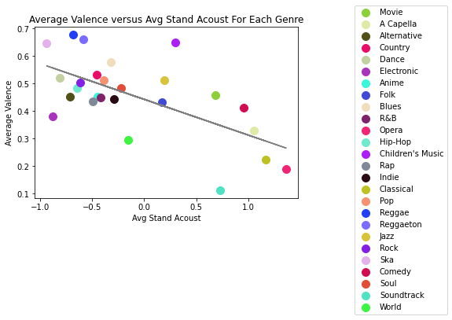

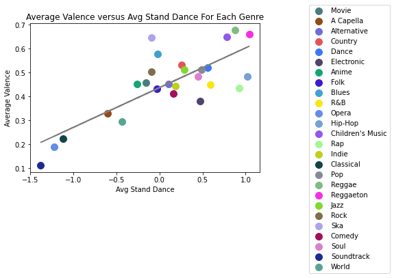

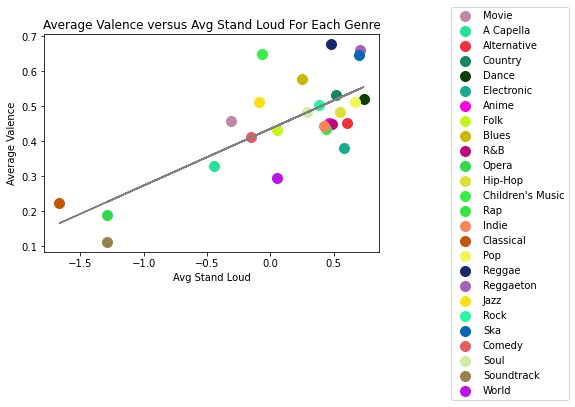

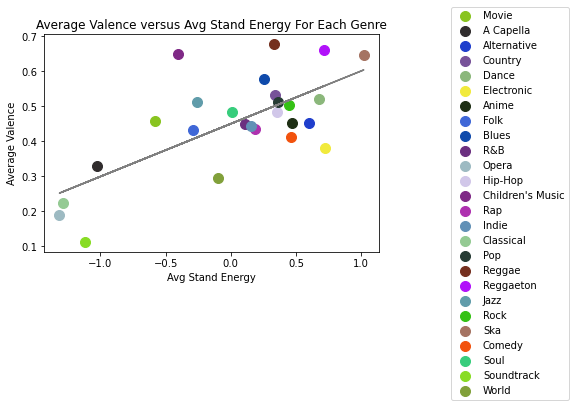

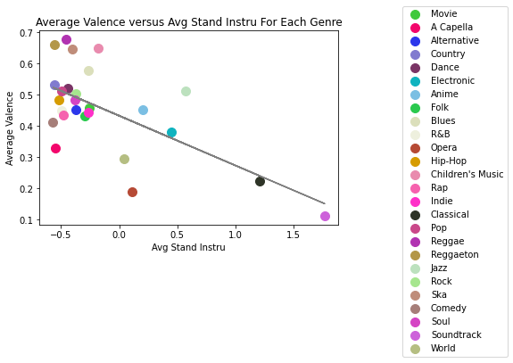

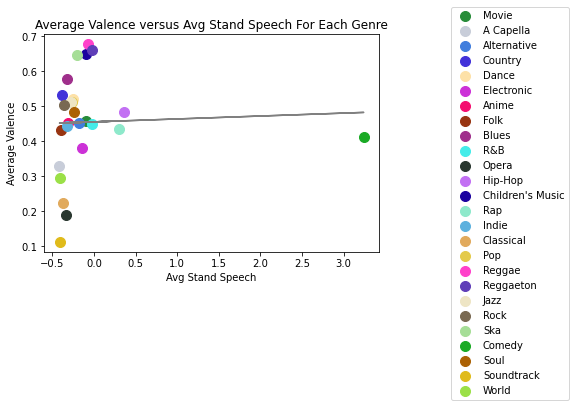

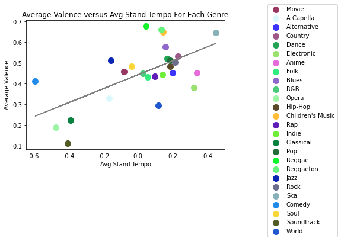

```python
audio_features = ['Avg Stand Acoust', 'Avg Stand Dance','Avg Stand Loud','Avg Stand Energy','Avg Stand Instru','Avg Stand Speech','Avg Stand Tempo']
for a in audio_features:
    sequence = np.arange(len(data.genre.unique()))
    for co in sequence:
        rgb = np.random.rand(3,)
        plt.scatter(genre_count[a][co], genre_count['Avg Val'][co], s =100, c = [rgb], label = list(genre_count["genre"])[co])


    plt.ylabel("Average Valence", size=10)
    plt.xlabel(a, size=10)
    plt.title("Average Valence versus " + a + " For Each Genre")
    plt.legend(loc="upper left", bbox_to_anchor=(1.2, 1.15))

    m, b = np.polyfit(genre_count[a], genre_count['Avg Val'], 1)
    plt.plot(genre_count[a], m*(genre_count[a])+b, color = "gray")

    plt.show()
```